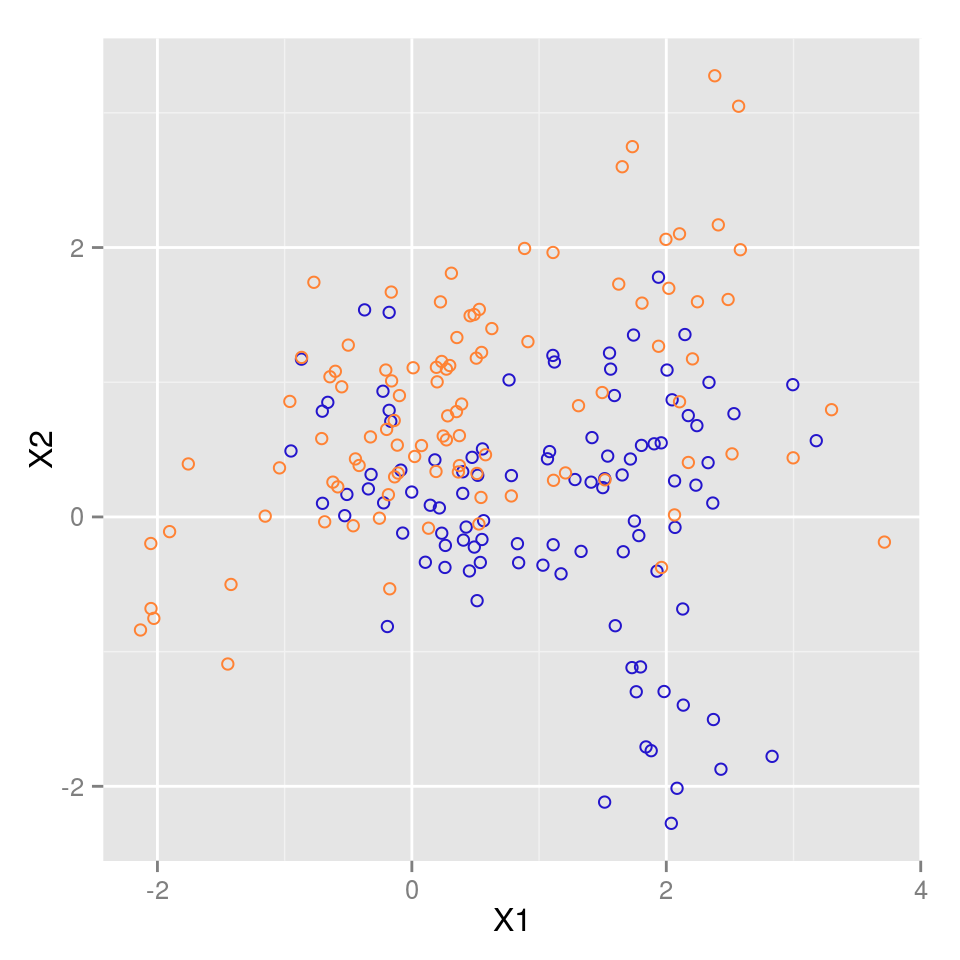

```r
library(MASS)
library(tibble)
library(ggplot2)

blue.mu = c(1,0)
og.mu = c(0,1)

blue.means = as_data_frame(mvrnorm(n=10, mu=blue.mu, Sigma=diag(2)))
blue.means$color = factor(rep(0,nrow(blue.means)), levels = c(0,1), labels = c("BLUE", "ORANGE"))
og.means = as_data_frame(mvrnorm(n=10, mu=og.mu, Sigma=diag(2)))
og.means$color = factor(rep(1, nrow(og.means)), levels = c(0,1), labels = c("BLUE", "ORANGE"))

blue.randmean = blue.means[sample(1:nrow(blue.means),100, replace = TRUE),1:2]
og.randmean = og.means[sample(1:nrow(og.means),100, replace = TRUE),1:2]

blue.data = as_data_frame(t(apply(blue.randmean, MARGIN=1, function(x) mvrnorm(n=1, mu=x, Sigma=diag(2)/5))))
og.data = as_data_frame(t(apply(og.randmean, MARGIN=1, function(x) mvrnorm(n=1, mu=x, Sigma=diag(2)/5))))
blue.data$color = factor(rep(0, nrow(blue.data)), levels = c(0,1), labels = c("BLUE", "ORANGE"))
og.data$color = factor(rep(1, nrow(og.means)), levels = c(0,1), labels = c("BLUE", "ORANGE"))

meandata = rbind(blue.means, og.means)
plotdata = rbind(blue.data, og.data)
(a = ggplot(data = plotdata, aes(x=V1, y=V2)) +
      geom_point(aes(color=color), size=2, shape=1) +
      #geom_point(data = meandata, aes(x=V1, y=V2, color=color), size=3) +
      scale_color_manual(values= c("#2415CC","#FF8234"), guide=FALSE) +
      xlab("X1") + ylab("X2"))
```

## **predict using linear regression**

Two-class classification problem. Denote the binary coded target as $Y$, and treat it as a quantitative output. Predictions $\hat Y$ will typically lie in $[0,1]$, and we can assign $\hat G$ the class label according to whether $\hat y > 0.5$.

Linear model:
$$\hat Y = X^T \hat \beta$$
Use method of least squares to fit $\hat \beta$ by minimizing the residual sum of squares:
$$\text{RSS}(\beta) = \sum_{i=1}^N (y_i - x_i^T \beta)^2$$
$\text{RSS}(\beta)$ is a quadratic function, and hence its minimum always exists, though it may not be unique. The solution is easiest to characterize in matrix notation:
$$\text{RSS}(\beta) = (\mathbf{y}- \mathbf{X} \beta)^T (\mathbf{y} - \mathbf{X} \beta)$$
, where $\mathbf{X} \in \mathbb{R}^{N \times p}$ with each row an input vector, and $\mathbf{y} \in \mathbb{R}^N$ representing the outputs in the training set. Differentiating w.r.t. $\beta$ we get the *normal equations*:
$$\mathbf{X}^T(\mathbf{y} - \mathbf{X}\beta) = 0$$
If $\mathbf{X}^T\mathbf{X}$ is nonsingular, then the unique solution is given by
$$\hat\beta = (\mathbf{X}^T \mathbf{X})^{-1} \mathbf{X}^T \mathbf{y}$$
, and the fitted value at the $i$th input $x_i$ is $\hat y_i = \hat y(x_i) = x_i^T \hat \beta$. At an arbitrary input $x_0$ the prediction is $\hat y(x_0) = x_0^T \hat \beta$. The entire fitted surface is characterized by the $p$ parameters $\hat \beta$.

Encode the output class variable $G$, which can take on the values BLUE or ORANGE, and encode it as a response $Y$ where $0$ is BLUE and $1$ is ORANGE. Then convert the fitted values $\hat Y$ to a fitted class variable $\hat G$ according to the rule:
$$\hat G = \begin{cases}
\text{ORANGE} & \text{if } \hat Y > 0.5 \\
\text{BLUE} & \text{if } \hat Y \leq 0.5
\end{cases}$$

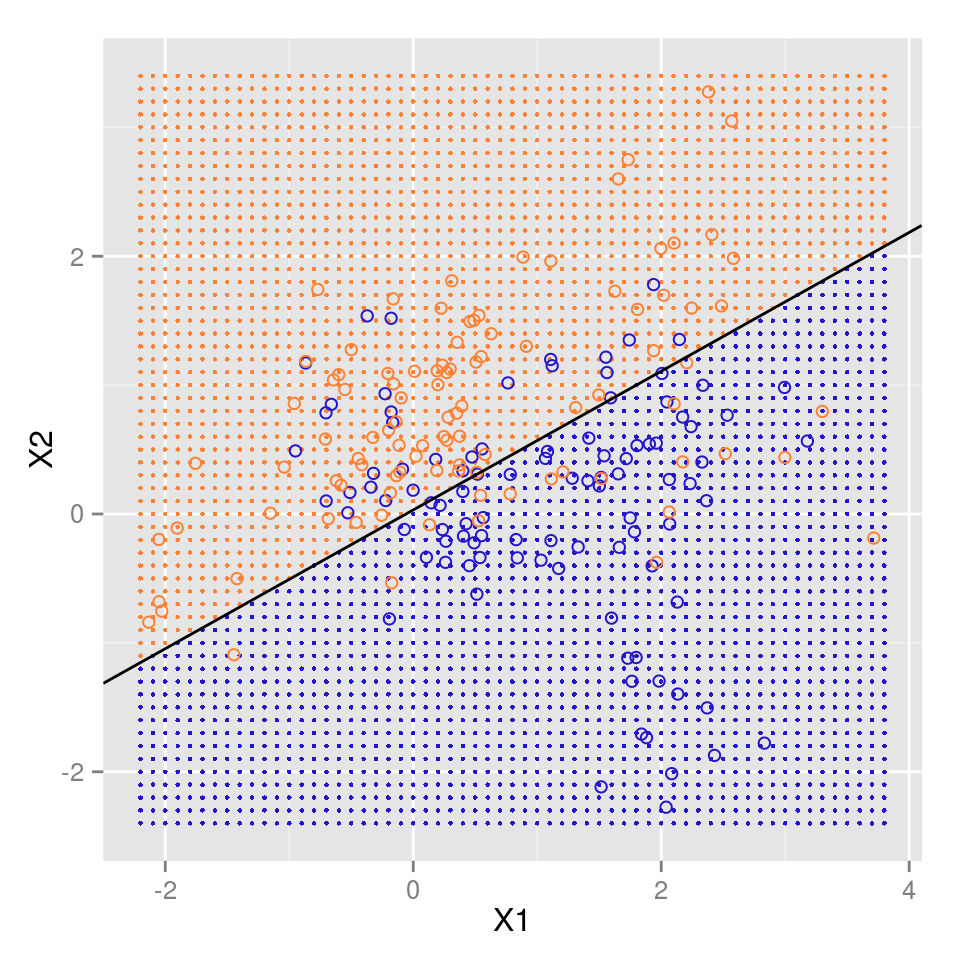

```r
X = as.matrix(cbind(rep(1, nrow(plotdata)), plotdata[,-3]))
y = ifelse(plotdata$color=="ORANGE", 1, 0)

beta.hat = solve(t(X) %*% X) %*% t(X) %*% y

#set ranges for grid based on ranges of training data
x.min = round(min(plotdata$V1), digits=1)-0.1
x.max = round(max(plotdata$V1), digits=1)+0.1
y.min = round(min(plotdata$V2), digits=1)-0.1
y.max = round(max(plotdata$V2), digits=1)+0.1

x.range = seq(from=x.min, to=x.max, by=0.1)
y.range = seq(from=y.min, to=y.max, by=0.1)

x.new = expand.grid(x.range, y.range)
names(x.new) = names(plotdata[,-3])

linreg.yhat = as.matrix(cbind(rep(1, nrow(x.new)), x.new)) %*% beta.hat
linreg.pred = ifelse(linreg.yhat>0.5,"ORANGE","BLUE")
linreg.plotdata = cbind(x.new, linreg.pred)

(b = ggplot() +
      geom_point(data = linreg.plotdata, aes(x=V1, y=V2, color=linreg.pred), size=0.8) +
      geom_point(data = plotdata, aes(x=V1, y=V2, color=color), size=2, shape=1) +
      geom_abline(slope = -beta.hat[2]/beta.hat[3], intercept = (.5-beta.hat[1])/beta.hat[3], color="black") +
      #geom_point(data = meandata, aes(x=V1, y=V2, color=color), size=3) +
      scale_color_manual(values= c("#2415CC","#FF8234"), guide=FALSE) +
      xlab("X1") + ylab("X2"))
```

## **predict using nearest-neighbor methods**

The $k$-nearest neighbor fit for $\hat Y$ is defined as follows:
$$\hat Y (x) = \frac{1}{k} \sum_{x_i \in N_k(x)} y_i$$

, where $N_k(x)$ is the neighborhood of $x$ defined by the $k$ closest points $x_i$ in the training sample, defined by Euclidean distance.

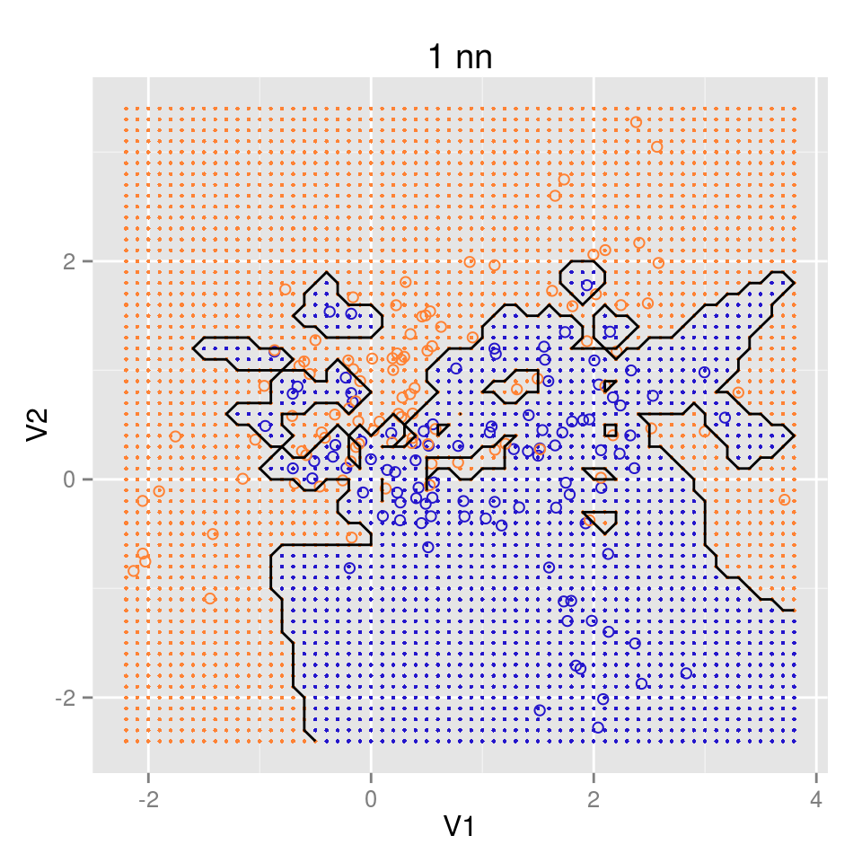

[figure not shown]

[figure not shown]

[figure not shown]

[figure not shown]

[figure not shown]

```r
#knn classification function:
#   inputs: xnew- a matrix of new x values to be classified
#           x- matrix of training inputs
#           y- vector of training labels
#           k- # of nearest neighbors parameter
myknn = function(xnew, x, y, k){
  N.new = nrow(xnew)
  ynew = numeric(N.new)

  allpoints = rbind(xnew, x)
  dmatrix = as.matrix(dist(allpoints))[seq(N.new+1, nrow(allpoints)),seq(1, N.new)]
  rownames(dmatrix) = 1:length(y)

  for (i in 1:N.new){
    dist.vector = dmatrix[,i]
    dist.sorted = sort(dist.vector)
    nn.indices = as.numeric(names(dist.sorted[1:k]))
    ynew[i] = sum(y[nn.indices])/k
  }
  return(ynew)
}

plotknn = function(k){
  knn.yhat = myknn(x.new, plotdata[,-3], y, k)
  knn.pred = ifelse(knn.yhat>0.5,"ORANGE","BLUE")
  knn.plotdata = as_data_frame(cbind(x.new, knn.pred))
  boundary.data = as_data_frame(cbind(x.new, knn.yhat))

  (c = ggplot() +
    geom_point(data=knn.plotdata, aes(x=V1, y=V2, color=knn.pred), size=.8) +
    geom_point(data=plotdata, aes(x=V1,y=V2, color=color), shape=1, size=2) +
    geom_contour(data=boundary.data, aes(x=V1,y=V2,z=knn.yhat), bins=1, color="black") +
    scale_color_manual(values= c("#2415CC","#FF8234"), guide=FALSE)) +
    ggtitle(paste(k, "nn"))
}
plotknn(k=1)
```